# PREGUNTAS

Dominguez Alondra.

2025-04-10

```r
library(igraph)
```

### PREGUNTAS.

**1. Considera una red de 15 nodos . Considera que tienes una sola conexión. ¿Cuál es el número máximo de nodos que puedes conectar? Dado un solo nodo , ¿cuál es el número máximo conexiones que puede tener tal nodo?**

Una sola conexion conecta a 2 nodos, se tiene un total de 14 conexiones para los 15 nodos si tomamos solo una conexion (salida–entrada a otro nodo). Asi que cada nodo solo puede tener 2 conexiones; la del nodo que lo conecta (in) y su conexion a otro nodo (out)

**2. Considera una red dirigida de 10 nodos. Usa 25 conexiones y dibuja una red con ese número de nodos y conexiones dirigidas. Calcula la distribución de conectividades de salida. Calcula el número total de conexiones de salida ¿Cómo se compara el número total de de conectividades de entrada (son iguales, diferentes)? Explica tu respuesta. Calcula el promedio de entrada y de salida. Discute tu resultado.**

Son los mismos valores, esto porque por cada nodo que entra hay un nodo de salida, no significa que esten conectados entre si, pero cada nodo tiene una entrada y una salida minimo. Por lo tanto el promedio debe de ser el mismo. De igual manera a pesar de que lhay nodos con varias entradas y salidad todos al menos tiene una.

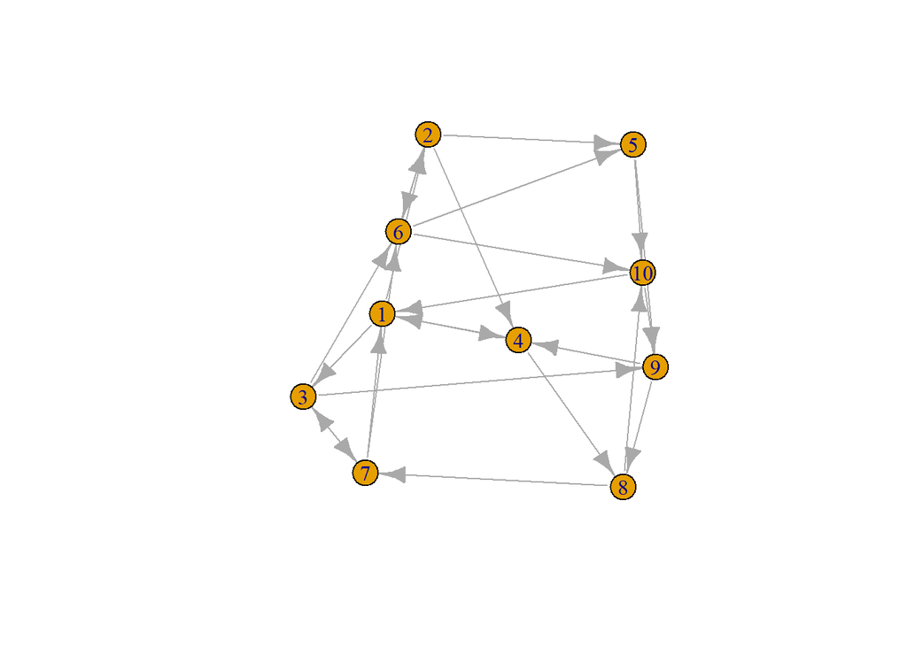

```r
g <- make_empty_graph(n = 10, directed = TRUE)


conexiones <- c(1,2, 1,3, 2,4, 2,5, 3,6,
  3,7, 4,1, 4,8, 5,9, 5,10,
  6,2, 6,5, 7,3, 7,6, 8,10,
  8,7, 9,4, 9,8, 10,1, 10,9,
  1,4, 2,6, 3,9, 6,10, 7,1)

# Agregar las aristas al grafo
g <- add_edges(g, conexiones)

plot(g)
```

```r
degree(g, mode = "out")->salida
sum(salida)
```

```
## [1] 25
```

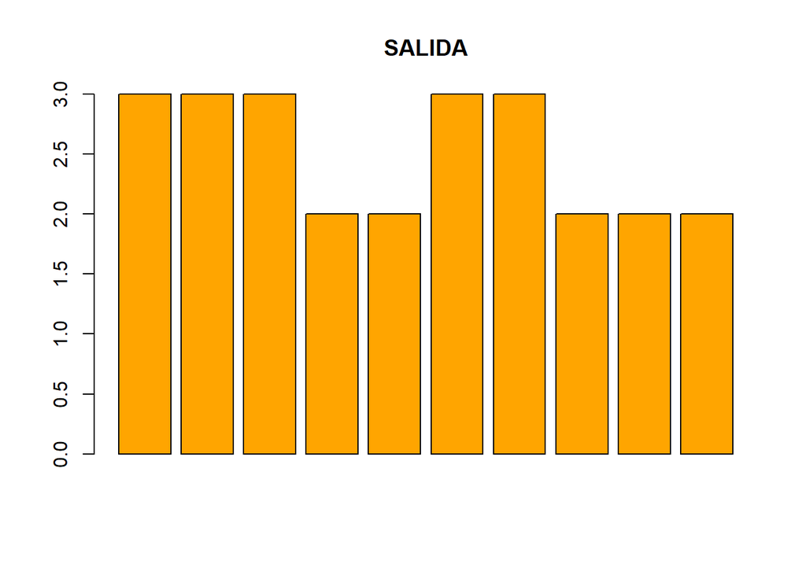

```r
barplot(salida, col = "orange", main ="SALIDA")
```

```r
degree(g, mode = "in")->entrada
sum(entrada)#---tambien son 25
```

```
## [1] 25
```

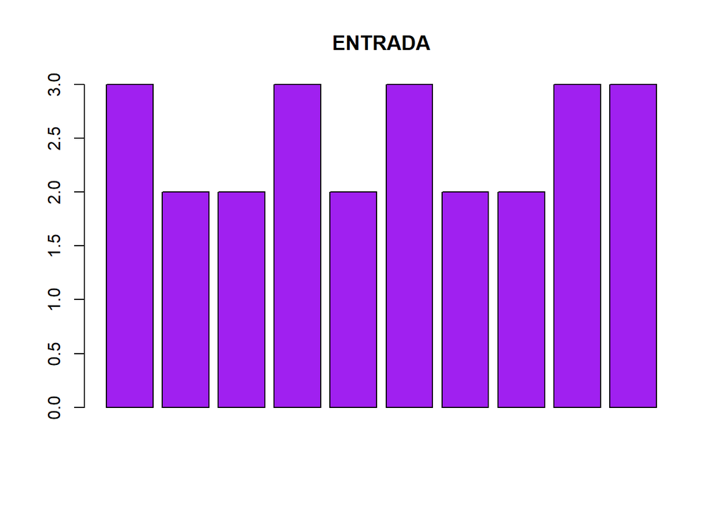

```r
barplot(entrada, col = "purple", main ="ENTRADA")
```

```r
degree(g, mode = "in")
```

```
##  [1] 3 2 2 3 2 3 2 2 3 3
```

```r
mean(salida)
```

```
## [1] 2.5
```

```r
mean(entrada)
```

```
## [1] 2.5
```

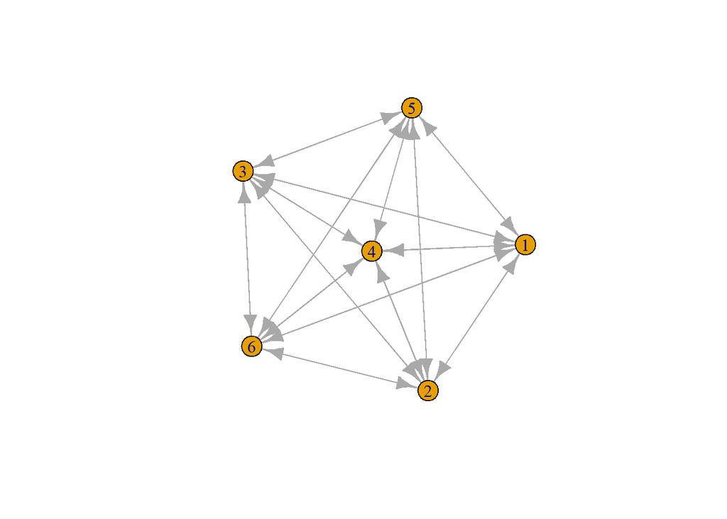

```r
 g5 <-make_full_graph(6, directed = TRUE)

 plot(g5)
```

```r
degree(g5)
```

```
## [1] 10 10 10 10 10 10
```

**3. Considera una red no dirigida de \(n=3,4,5,6\) nodos respectivamente. ¿Cuál es el número máximo de conexiones que puedes poner? Dibuja cada caso. ¿Qué pasa si la red es dirigida?**

RED 3: 3

RED4: 6

RED5: 10

Se tendria el doble de conexiones para que el nodo A conecte al nodo B para ser igual a la no dirigida.

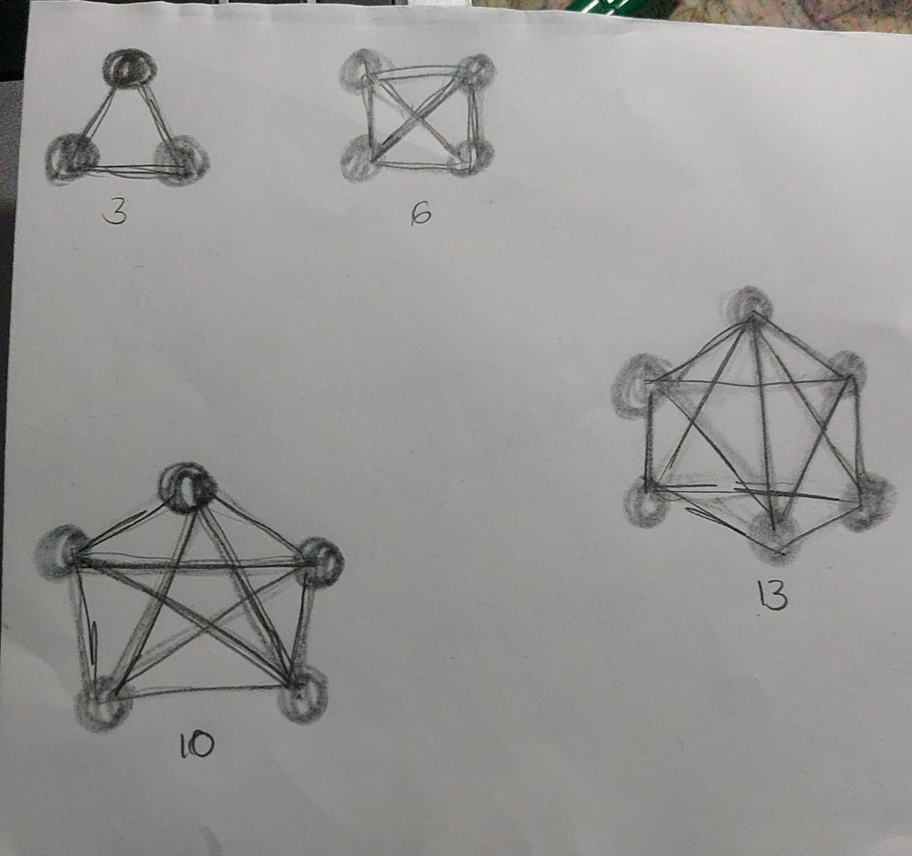

**4. Considera tu red de amigos reales.¿ Cuál es tu coeficiente de clusterización?** De 1 para una parte de la red y de 0 para las otras partes.

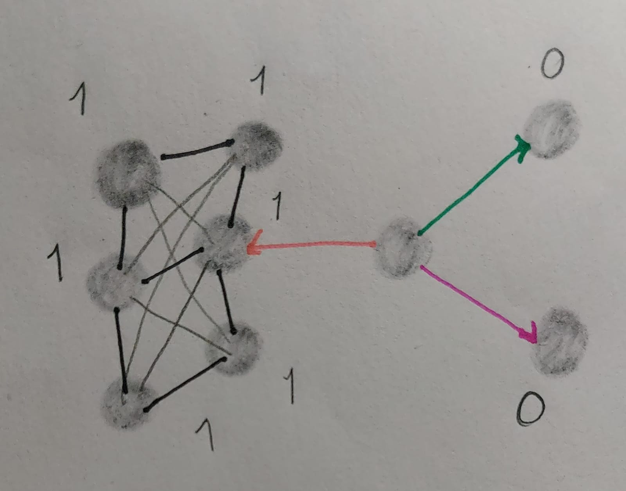

### **CALCULO A MANO DE LAS REDES:**

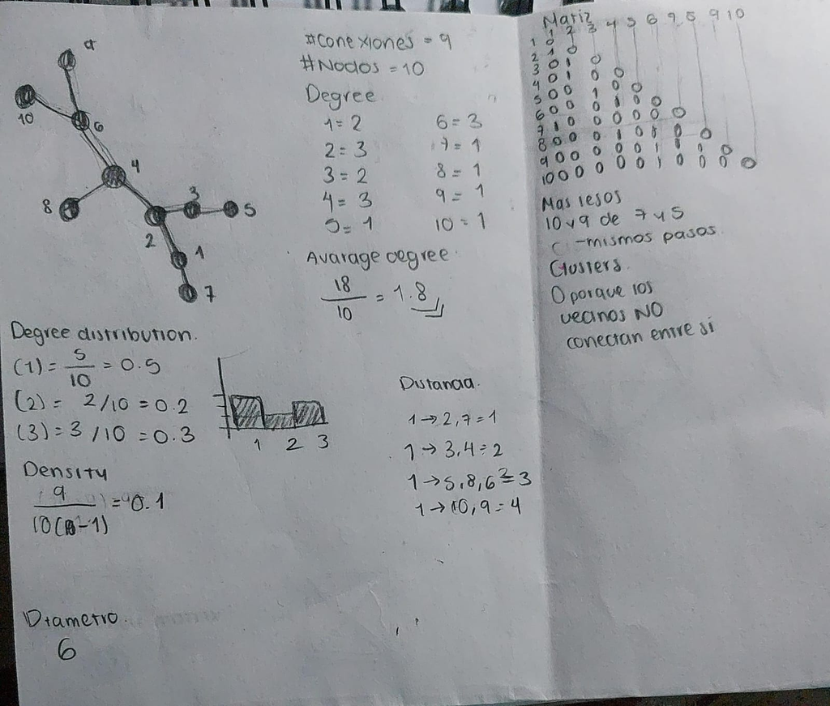

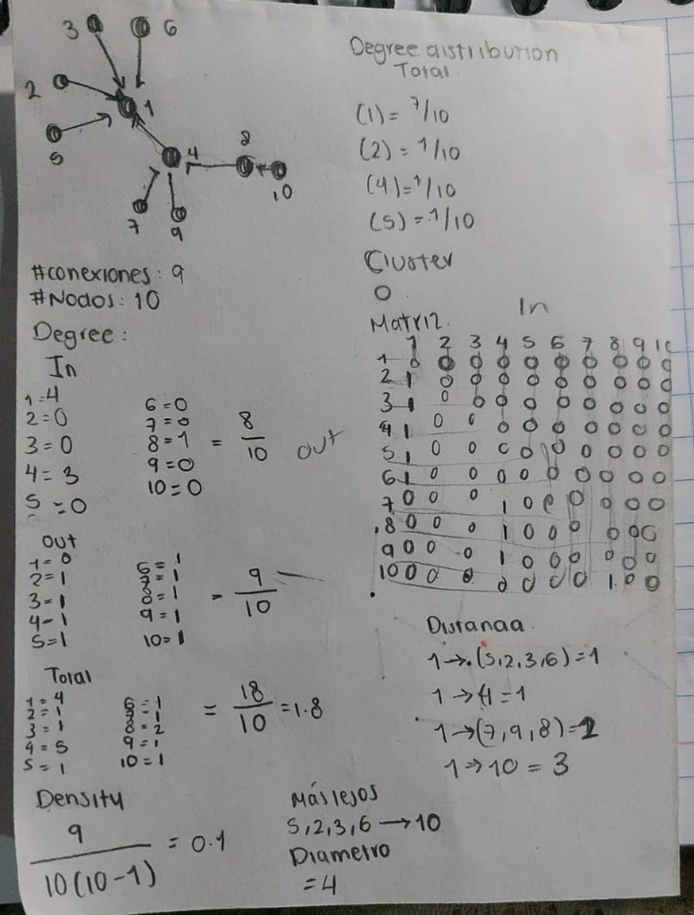

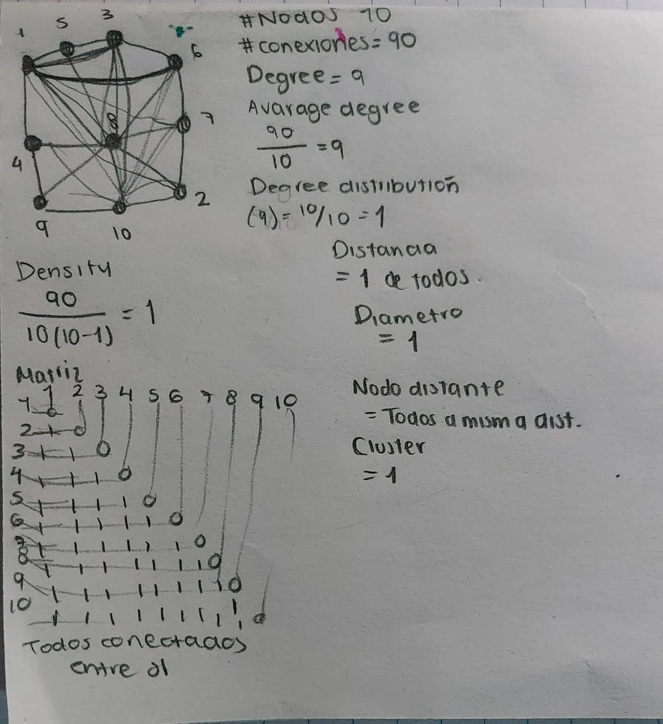

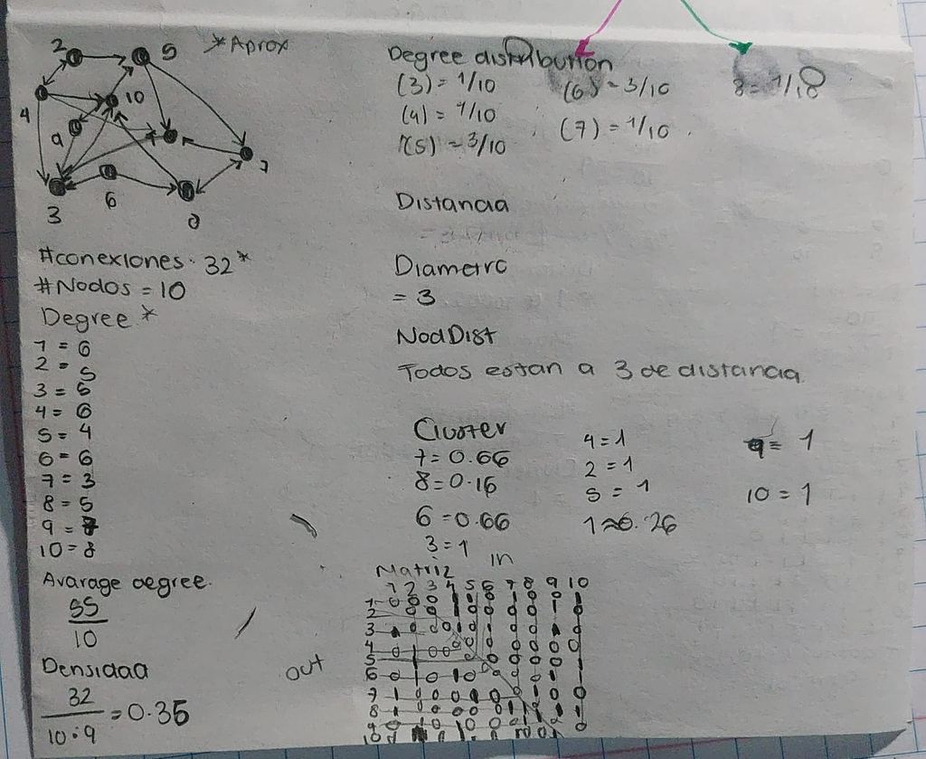

[figure not shown]

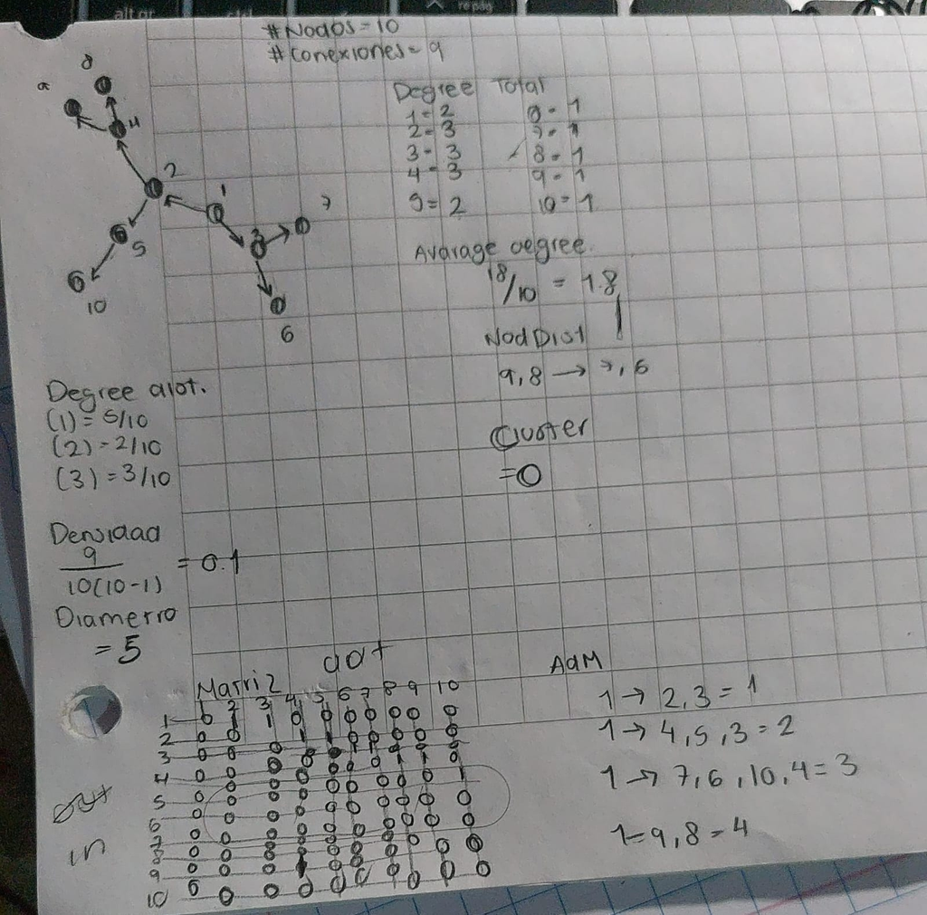

### **ZACHARY**

```r
library(igraph)
karate<-make_graph("Zachary")
```

- **¿Cuántos nodos y conexiones tiene?**

  34
- **¿Quiénes son los nodos y cuál es la regla de conexión?**

  El nodo 1 representa al entrenador y el nodo 34 al administrador y presidente del club. Cada nodo indica a un miembro del club de karate y las interacciones que tuvieron fuera del club. Ademas representa el momento donde se separo el club y como se acomodaron los miembros.
- **¿Qué tan densa es la red?**

  Tiene una densidad de 0.06951872. Esto indica que hay menos conexiones entre los miembros, lo que indica que la red tiene partes fragmentadas, considerando que la red se separo por motivos sociales tiene relacion la baja densidad.
- **¿Cómo obtienes la matriz de adyacencia?.**

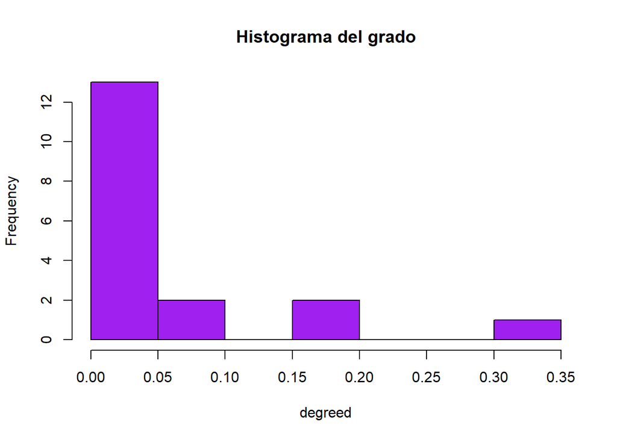

  ```r
  degree_distribution(karate)->degreed
  hist(degreed, , col="purple", main="Histograma del grado")
  ```

- **Calcula el diámetro, la matriz de distancias y la distancia promedio**

  ```
  ## [1] 78
  ## #conexiones: 78
  ## [1] 34
  ## #nodos: 34
  ##  [1] 16  9 10  6  3  4  4  4  5  2  3  1  2  5  2  2  2  2  2  3  2  2  2  5  3
  ## [26]  3  2  4  3  4  4  6 12 17
  ## #degree: 16 9 10 6 3 4 4 4 5 2 3 1 2 5 2 2 2 2 2 3 2 2 2 5 3 3 2 4 3 4 4 6 12 17
  ##  [1] 0.47058824 0.26470588 0.29411765 0.17647059 0.08823529 0.11764706
  ##  [7] 0.11764706 0.11764706 0.14705882 0.05882353 0.08823529 0.02941176
  ## [13] 0.05882353 0.14705882 0.05882353 0.05882353 0.05882353 0.05882353
  ## [19] 0.05882353 0.08823529 0.05882353 0.05882353 0.05882353 0.14705882
  ## [25] 0.08823529 0.08823529 0.05882353 0.11764706 0.08823529 0.11764706
  ## [31] 0.11764706 0.17647059 0.35294118 0.50000000
  ## degreeavarage: 0.4705882 0.2647059 0.2941176 0.1764706 0.08823529 0.1176471 0.1176471 0.1176471 0.1470588 0.05882353 0.08823529 0.02941176 0.05882353 0.1470588 0.05882353 0.05882353 0.05882353 0.05882353 0.05882353 0.08823529 0.05882353 0.05882353 0.05882353 0.1470588 0.08823529 0.08823529 0.0588…
  ```

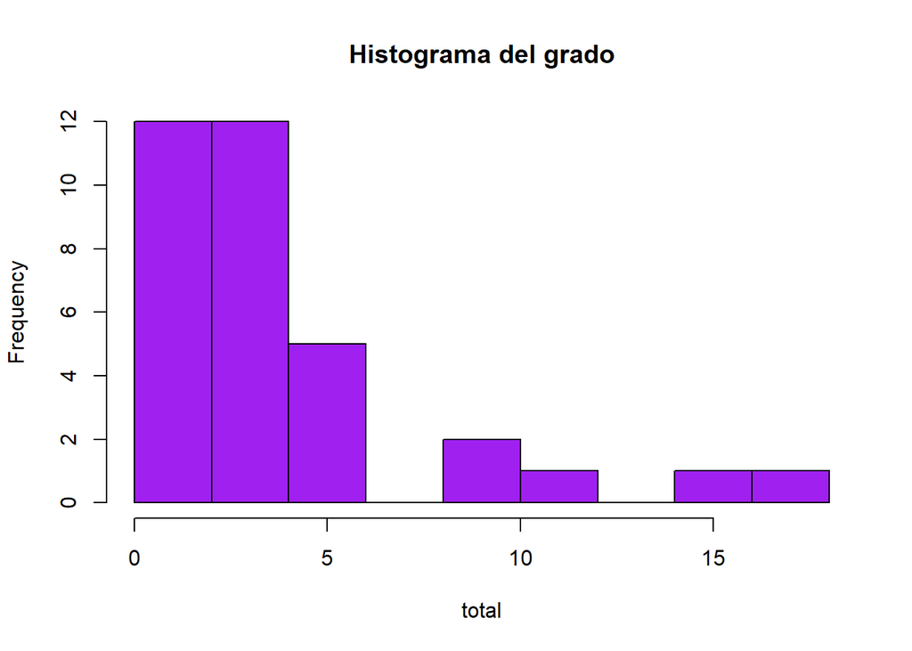

  ```
  ## [1] 0.06951872
  ## densidad: 0.06951872
  ```

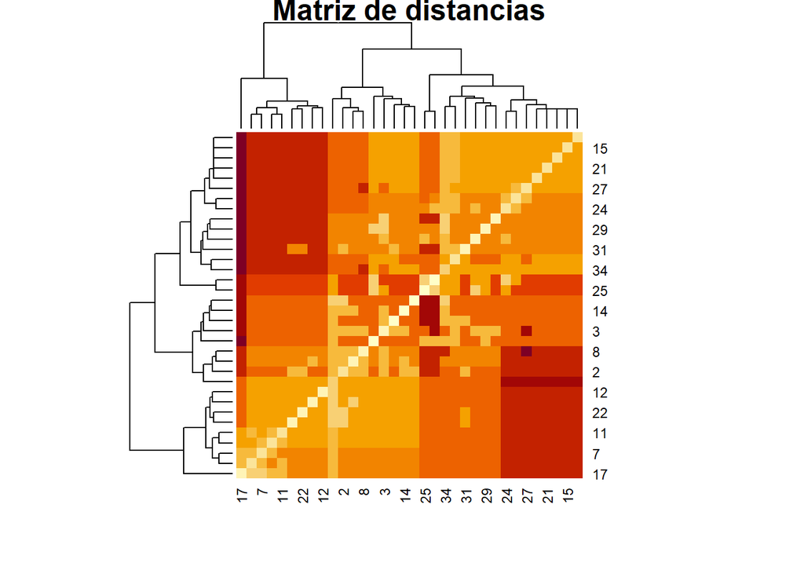

  ```
  ## [1] 5
  ## diametro: 5
  ##  [1] 0.1500000 0.3333333 0.2444444 0.6666667 0.6666667 0.5000000 0.5000000
  ##  [8] 1.0000000 0.5000000 0.0000000 0.6666667       NaN 1.0000000 0.6000000
  ## [15] 1.0000000 1.0000000 1.0000000 1.0000000 1.0000000 0.3333333 1.0000000
  ## [22] 1.0000000 1.0000000 0.4000000 0.3333333 0.3333333 1.0000000 0.1666667
  ## [29] 0.3333333 0.6666667 0.5000000 0.2000000 0.1969697 0.1102941
  ## cluster local: 0.15 0.3333333 0.2444444 0.6666667 0.6666667 0.5 0.5 1 0.5 0 0.6666667 NaN 1 0.6 1 1 1 1 1 0.3333333 1 1 1 0.4 0.3333333 0.3333333 1 0.1666667 0.3333333 0.6666667 0.5 0.2 0.1969697 0.1102941
  ```

  ```r
  source("FUNCION.R")
  karate<-make_graph("Zachary")
  calculo_total(karate)
  ```